# F

## Programming Fundation (Udacity) - Final Project: Exploring Titanic Data.

### 1. Description of the dataset:

The data could be downloaded from the Kaggel (https://www.kaggle.com/c/titanic), a website for learning data analytics. The raw data consists of 891 observations and 12 variables

An overview of the variables is as follows:

Nominal variables (Categorical variables which do not have intrinsic order) -->

- Sex (as strings): "Female" or "Male"
- Embarked (as strings): Port of Embarkation (C = Cherbourg; Q = Queentown; S = Southampton)
- Cabin (as strings): Cabin name
- Name (as strings): Passengers' name in the form of "Last name, Prefix. First name "
- Ticket (as strings): Ticket number
- Survived (as integers): 0 = No; 1 = yes.

Ordinal variables (Categorical variables with intrinsic order) -->

- PassengerId (as integers): An attribute which allows us to identify each passenger uniquely.
- Pclass (as integers): Passenger Class 1 - 1st; 2 - 2nd; 3 - 3rd.

Continuous variables -->

- Age (as float variables): Age in years. if age is less than 1, it is fractional.
- SibSp (as integers): Number of Siblings/Spouses
- Parch (as integers): Number of Parents/Children
- Fare (as float variables): Ticket Price

### Questions to be addressed:

We are interested in what factors impact survival. Having done a preliminary examination of the dataset, I decide to break this question into several parts.

1. Did gender influence survival rate?
2. Did passenger class influence survival rate?
   - If so, Why exactly?
3. How do survival rates vary for different age groups?
4. Do families with larger size survive more often?
   - Do people who travel together survive more often?

```python
import numpy as np
import pandas as pd
import matplotlib.pyplot as plt
import seaborn as sns
%matplotlib inline
%pylab inline
```

```python
# read csv data into a pandas dataframe object.
t_data= pd.read_csv(r'C:\Users\bisheng\Desktop\coursera\1udacity\introtodataanalysis\titanic_data.csv')
```

```python
# An overview of the variables in the data.
t_data.info()
```

```
<class 'pandas.core.frame.DataFrame'>
RangeIndex: 891 entries, 0 to 890
Data columns (total 12 columns):
PassengerId    891 non-null int64
Survived       891 non-null int64
Pclass         891 non-null int64
Name           891 non-null object
Sex            891 non-null object
Age            714 non-null float64
SibSp          891 non-null int64
Parch          891 non-null int64
Ticket         891 non-null object
Fare           891 non-null float64
Cabin          204 non-null object
Embarked       889 non-null object
dtypes: float64(2), int64(5), object(5)
memory usage: 83.6+ KB
```

```python
# describe the numerical variables.
t_data.describe(include = ['number'])
```

|  | PassengerId | Survived | Pclass | Age | SibSp | Parch | Fare |
| --- | --- | --- | --- | --- | --- | --- | --- |
| count | 891.000000 | 891.000000 | 891.000000 | 714.000000 | 891.000000 | 891.000000 | 891.000000 |
| mean | 446.000000 | 0.383838 | 2.308642 | 29.699118 | 0.523008 | 0.381594 | 32.204208 |
| std | 257.353842 | 0.486592 | 0.836071 | 14.526497 | 1.102743 | 0.806057 | 49.693429 |
| min | 1.000000 | 0.000000 | 1.000000 | 0.420000 | 0.000000 | 0.000000 | 0.000000 |
| 25% | 223.500000 | 0.000000 | 2.000000 | NaN | 0.000000 | 0.000000 | 7.910400 |
| 50% | 446.000000 | 0.000000 | 3.000000 | NaN | 0.000000 | 0.000000 | 14.454200 |
| 75% | 668.500000 | 1.000000 | 3.000000 | NaN | 1.000000 | 0.000000 | 31.000000 |
| max | 891.000000 | 1.000000 | 3.000000 | 80.000000 | 8.000000 | 6.000000 | 512.329200 |

```python
# describe the "object" variables.
t_data.describe(include = ['object'])
```

|  | Name | Sex | Ticket | Cabin | Embarked |
| --- | --- | --- | --- | --- | --- |
| count | 891 | 891 | 891 | 204 | 889 |
| unique | 891 | 2 | 681 | 147 | 3 |
| top | Graham, Mr. George Edward | male | CA. 2343 | C23 C25 C27 | S |
| freq | 1 | 577 | 7 | 4 | 644 |

1. There are small amount of missing values for the variables "Age" and "Embarked", Massive missing values for "cabin".
2. The lowest Fare is zero. (Those should be staffs of Titanic.) The distribution of "Fare" is quite wide ranged, which suggests the possibility of outliers.
3. People can share the same ticket number, which indicates that they might travel together.

```python
t_data.head()
```

|  | PassengerId | Survived | Pclass | Name | Sex | Age | SibSp | Parch | Ticket | Fare | Cabin | Embarked |
| --- | --- | --- | --- | --- | --- | --- | --- | --- | --- | --- | --- | --- |
| 0 | 1 | 0 | 3 | Braund, Mr. Owen Harris | male | 22.0 | 1 | 0 | A/5 21171 | 7.2500 | NaN | S |
| 1 | 2 | 1 | 1 | Cumings, Mrs. John Bradley (Florence Briggs Th... | female | 38.0 | 1 | 0 | PC 17599 | 71.2833 | C85 | C |
| 2 | 3 | 1 | 3 | Heikkinen, Miss. Laina | female | 26.0 | 0 | 0 | STON/O2. 3101282 | 7.9250 | NaN | S |
| 3 | 4 | 1 | 1 | Futrelle, Mrs. Jacques Heath (Lily May Peel) | female | 35.0 | 1 | 0 | 113803 | 53.1000 | C123 | S |
| 4 | 5 | 0 | 3 | Allen, Mr. William Henry | male | 35.0 | 0 | 0 | 373450 | 8.0500 | NaN | S |

### 2. Data wrangling

#### 2.0 Manipulating the variable "Name".

Name is of format {Last name}, {Prefix.} {First name}. One good reason of breaking Passenger names into their "last name", "prefix" and "first name" is: "Prefix" is closely related to "Age" and "Sex".

```python
# Import regular expression library.
import re

# I now define a function to extract the title for each name string.

def extract_title(a_string):
   return re.sub('(.*, )|(\\..*)', "", a_string)

t_data["prefix"] = t_data["Name"].apply(extract_title)
```

```python
# The following code shows the distinct prefixes, and their corresponding occurances.
t_data["prefix"].value_counts()

# Use t_data["prefix"].value_counts().sum() to confirm that all the passengers have prefix.
```

```
Mr              517
Miss            182
Mrs             125
Master           40
Dr                7
Rev               6
Mlle              2
Col               2
Major             2
Lady              1
Jonkheer          1
Don               1
Ms                1
Mme               1
Capt              1
the Countess      1
Sir               1
Name: prefix, dtype: int64
```

```python
# Now I break the name into Last_name, the prefix, as well as the First_name.

for index, row in t_data.iterrows():
    t_data.loc[index, "Last_Name"] = t_data["Name"].str.split(",").iloc[index][0]
    if t_data.loc[index, "prefix"] == False:
        t_data.loc[index, "First_Name"] = t_data["Name"].str.split(", ").iloc[index][1]
    else:
        t_data.loc[index, "First_Name"] = row["Name"].split(". ")[1]

# Alternatively, we could also use the apply() method to achieve the results.

t_data.head()
```

|  | PassengerId | Survived | Pclass | Name | Sex | Age | SibSp | Parch | Ticket | Fare | Cabin | Embarked | prefix | Last_Name | First_Name |
| --- | --- | --- | --- | --- | --- | --- | --- | --- | --- | --- | --- | --- | --- | --- | --- |
| 0 | 1 | 0 | 3 | Braund, Mr. Owen Harris | male | 22.0 | 1 | 0 | A/5 21171 | 7.2500 | NaN | S | Mr | Braund | Owen Harris |
| 1 | 2 | 1 | 1 | Cumings, Mrs. John Bradley (Florence Briggs Th... | female | 38.0 | 1 | 0 | PC 17599 | 71.2833 | C85 | C | Mrs | Cumings | John Bradley (Florence Briggs Thayer) |
| 2 | 3 | 1 | 3 | Heikkinen, Miss. Laina | female | 26.0 | 0 | 0 | STON/O2. 3101282 | 7.9250 | NaN | S | Miss | Heikkinen | Laina |
| 3 | 4 | 1 | 1 | Futrelle, Mrs. Jacques Heath (Lily May Peel) | female | 35.0 | 1 | 0 | 113803 | 53.1000 | C123 | S | Mrs | Futrelle | Jacques Heath (Lily May Peel) |
| 4 | 5 | 0 | 3 | Allen, Mr. William Henry | male | 35.0 | 0 | 0 | 373450 | 8.0500 | NaN | S | Mr | Allen | William Henry |

```python
# Drop the name colomn.
t_data = t_data.drop("Name",axis = 1)
```

#### 2.1 Investigating Missing values ("Age" and "Embarked").

The code below displays the percentage (in units of %) of missing data.

```python
(t_data.isnull().sum()/t_data["PassengerId"].count()) * 100
```

```
PassengerId     0.000000
Survived        0.000000
Pclass          0.000000
Sex             0.000000
Age            19.865320
SibSp           0.000000
Parch           0.000000
Ticket          0.000000
Fare            0.000000
Cabin          77.104377
Embarked        0.224467
prefix          0.000000
Last_Name       0.000000
First_Name      0.000000
dtype: float64
```

There is reasonable amount of missing values for "Age" and "Embarked", so it is possible to find reasonable ways to fill these missing values.

With large amount of missing values for "Cabin", I would not try to fill these missing values. I will retain this variable, keeping the possibility of making use of it for side observations open.

#### 2.1.0 Age

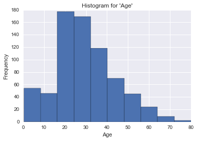

```python
# I plot histogram of Age (for non-missing values). There are 10 bins by default: bins = 10.
ax_age = t_data["Age"].plot.hist()
ax_age.set_title("Histogram for 'Age'")
ax_age.set(xlabel = "Age")
```

```python
# The range of "Age" is large, there are potentially outliers.
# I could define a helper function to get the Interquarter range for the purpose of detecting outliers.
def get_IQR(a1_series):
    Q1 = a1_series.quantile(0.25)
    Q3 = a1_series.quantile(0.75)
    IQR = Q3 - Q1
    return Q1 - IQR * 1.5, Q3 + IQR * 1.5

# The outliers are defined as those points which are situated outside of the IQR.
# The following code returns the outliers.

t_data[t_data["Age"] > get_IQR(t_data.loc[t_data["Age"].isnull() != True, "Age"])[1]]
```

|  | PassengerId | Survived | Pclass | Sex | Age | SibSp | Parch | Ticket | Fare | Cabin | Embarked | prefix | Last_Name | First_Name |
| --- | --- | --- | --- | --- | --- | --- | --- | --- | --- | --- | --- | --- | --- | --- |
| 33 | 34 | 0 | 2 | male | 66.0 | 0 | 0 | C.A. 24579 | 10.5000 | NaN | S | Mr | Wheadon | Edward H |
| 54 | 55 | 0 | 1 | male | 65.0 | 0 | 1 | 113509 | 61.9792 | B30 | C | Mr | Ostby | Engelhart Cornelius |
| 96 | 97 | 0 | 1 | male | 71.0 | 0 | 0 | PC 17754 | 34.6542 | A5 | C | Mr | Goldschmidt | George B |
| 116 | 117 | 0 | 3 | male | 70.5 | 0 | 0 | 370369 | 7.7500 | NaN | Q | Mr | Connors | Patrick |
| 280 | 281 | 0 | 3 | male | 65.0 | 0 | 0 | 336439 | 7.7500 | NaN | Q | Mr | Duane | Frank |
| 456 | 457 | 0 | 1 | male | 65.0 | 0 | 0 | 13509 | 26.5500 | E38 | S | Mr | Millet | Francis Davis |
| 493 | 494 | 0 | 1 | male | 71.0 | 0 | 0 | PC 17609 | 49.5042 | NaN | C | Mr | Artagaveytia | Ramon |
| 630 | 631 | 1 | 1 | male | 80.0 | 0 | 0 | 27042 | 30.0000 | A23 | S | Mr | Barkworth | Algernon Henry Wilson |
| 672 | 673 | 0 | 2 | male | 70.0 | 0 | 0 | C.A. 24580 | 10.5000 | NaN | S | Mr | Mitchell | Henry Michael |
| 745 | 746 | 0 | 1 | male | 70.0 | 1 | 1 | WE/P 5735 | 71.0000 | B22 | S | Capt | Crosby | Edward Gifford |
| 851 | 852 | 0 | 3 | male | 74.0 | 0 | 0 | 347060 | 7.7750 | NaN | S | Mr | Svensson | Johan |

#### Some interesting observations.

- All the outliers with respect to "Age" are male. Most of them are in the middle-upper class.
- Except for the oldest one, none survived.
- Most of them seem to travel alone: "SibSp" and "Parch" appear to be 0. However, it is possible that they were travelling with servants or other friends.

###### 2.1.0.1 Fill the missing values for "Age"

```python
# The following code helps me identify the prefixes which the missing "Age" values are coming from.

t_data.loc[t_data["Age"].isnull() == True]["prefix"].unique()
```

```
array(['Mr', 'Mrs', 'Miss', 'Master', 'Dr'], dtype=object)
```

The missing "Age" values are coming from the following prefixes: ['Mr', 'Mrs', 'Miss', 'Master', 'Dr']. I suspect that one's "prefix" tells something about one's "Age". I thus draw the distribution of (non missing) "Age", given one's prefix.

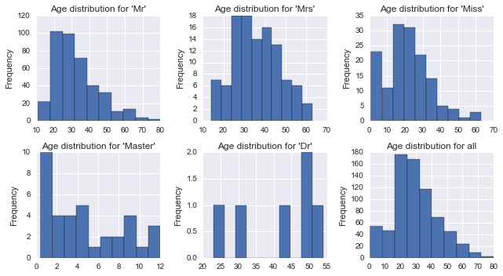

```python
# .subplots() returns an instance of Figure, along with an array of Axes for each subplot.
fig, axes = plt.subplots(nrows=2, ncols=3)
fig.set_size_inches(w=9,h=5)
t_data.loc[t_data["prefix"] == "Mr", "Age"].plot.hist(ax=axes[0,0]);
axes[0,0].set_title("Age distribution for 'Mr'")
t_data.loc[t_data["prefix"] == "Mrs", "Age"].plot.hist(ax=axes[0,1]);
axes[0,1].set_title("Age distribution for 'Mrs'")
t_data.loc[t_data["prefix"] == "Miss", "Age"].plot.hist(ax=axes[0,2]);
axes[0,2].set_title("Age distribution for 'Miss'")
t_data.loc[t_data["prefix"] == "Master", "Age"].plot.hist(ax=axes[1,0]);
axes[1,0].set_title("Age distribution for 'Master'")
t_data.loc[t_data["prefix"] == "Dr", "Age"].plot.hist(ax=axes[1,1]);
axes[1,1].set_title("Age distribution for 'Dr'")
t_data["Age"].plot.hist(ax=axes[1,2]); axes[1,2].set_title('Age distribution for all')
plt.tight_layout()
```

##### Observations.

Given the prefix (and hence Sex), conditional age distributions have different ranges and shapes. A good example is that the Masters are all of age less than 12. These suggest that we could do better than simply filling the missing values by the median of the unconditional age distribution.

##### --------------------

I decide to fill the missingg values using median, mode or mean of the Age distribution conditional on their respective prefix: for those with prefix "Mr.", "Mrs", and "Miss", it may be reasonable to fill missing ages with medians since the mode and median are close; It may be more appropriate to assign the mode to the "Master"s, and mean to the "Doctors".

```python
# I get the respective median age conditional on the prefix Mr, Mrs, Miss

Mr_median_age = t_data.loc[(t_data["prefix"] == "Mr") & (t_data["Age"].isnull() != True), "Age"].median()
# To verify:  t_data.loc[(t_data["prefix"] == "Mr") & (t_data["Age"].isnull() != True), "Age"].describe()

Mrs_median_age = t_data.loc[(t_data["prefix"] == "Mrs") & (t_data["Age"].isnull() != True), "Age"].median()
# To verify:  t_data.loc[(t_data["prefix"] == "Mrs") & (t_data["Age"].isnull() != True), "Age"].describe()

Miss_median_age = t_data.loc[(t_data["prefix"] == "Miss") & (t_data["Age"].isnull() != True), "Age"].median()
# To verify:  t_data.loc[(t_data["prefix"] == "Miss") & (t_data["Age"].isnull() != True), "Age"].describe()


# print Mr_median_age, Mrs_median_age, Miss_median_age
```

```python
# I get the respective mode age conditional on the prefix Master, the mean for Dr.

Master_mode_age = t_data.loc[(t_data["prefix"] == "Master") & (t_data["Age"].isnull() != True), "Age"].mode().iloc[0]
# To verify:  t_data.loc[(t_data["prefix"] == "Master") & (t_data["Age"].isnull() != True), "Age"].value_counts()
# Notice that .mode() method can return a series.

Dr_mean_age = t_data.loc[(t_data["prefix"] == "Dr") & (t_data["Age"].isnull() != True), "Age"].mean()
# To verify:  t_data.loc[(t_data["prefix"] == "Dr") & (t_data["Age"].isnull() != True), "Age"].describe()
```

```python
# I now create a new column "age_filled", in which the missing values are filled.
# Based on this new column, I create a categorical variables age group.

t_data["age_filled"] = pd.Series(t_data["Age"], index=t_data.index)
t_data.loc[(t_data["prefix"] == "Mr") & (t_data["age_filled"].isnull()), "age_filled"] = Mr_median_age
t_data.loc[(t_data["prefix"] == "Mrs") & (t_data["age_filled"].isnull()), "age_filled"] = Mrs_median_age
t_data.loc[(t_data["prefix"] == "Miss") & (t_data["age_filled"].isnull()), "age_filled"] = Miss_median_age
t_data.loc[(t_data["prefix"] == "Master") & (t_data["age_filled"].isnull()), "age_filled"] = Master_mode_age
t_data.loc[(t_data["prefix"] == "Dr") & (t_data["age_filled"].isnull()), "age_filled"] = Dr_mean_age
t_data[["age_filled", "Age"]].describe()
```

|  | age_filled | Age |
| --- | --- | --- |
| count | 891.000000 | 714.000000 |
| mean | 29.373928 | 29.699118 |
| std | 13.282625 | 14.526497 |
| min | 0.420000 | 0.420000 |
| 25% | 21.000000 | NaN |
| 50% | 30.000000 | NaN |
| 75% | 35.000000 | NaN |
| max | 80.000000 | 80.000000 |

###### 2.1.0.2 Create an ordinal categorical variables Age group.

When I plotted the histogram, I notice that the there are 10 bins by default, that is to say, the bin size is 8. For number of bins less than 10, the shape of the histogram will greatly change at the lower tail. For number of bins greater than or equal to 10, the shape of the histogram will be very similar. So I will choose to put the ages into 10 categories.

```python
# To get: [0, 8, 16, 24, 32, 40, 48, 56, 64, 72, 80]
bin_separators = range(0,81,8)

# to get: age_groups = ['age_0_8', 'age_8_16', 'age_16_24', 'age_24_32','age_32_40',
#                       'age_40_48', 'age_48_56', 'age_56_64', 'age_64_72', 'age_72_80']
age_groups = ["age_{}_{}".format(bin_separators[x],bin_separators[x+1]) for x in range(10)]

# The following returns a series with type "Category", not "object"
t_data['Age_groups'] = pd.cut(t_data["age_filled"], bin_separators, labels=age_groups)

pd.value_counts(t_data['Age_groups'])
```

```
age_24_32    288
age_16_24    213
age_32_40    135
age_40_48     71
age_0_8       58
age_8_16      46
age_48_56     45
age_56_64     24
age_64_72      9
age_72_80      2
Name: Age_groups, dtype: int64
```

Here, I will conduct a goodness-of-fit Chi square test to confirm that the distribution of age conditional on the prefix is indeed siginificantly different from the unconditional age distribution.

```python
# First step: I will create a helper function for obtaining the array for the observed frequencies.
def relative_freq_series(title):
    absolute_freq_series = t_data.loc[(t_data["Age"].isnull() == False) & (t_data["prefix"] == title), "Age_groups"].value_counts()
    rel_freq_series = absolute_freq_series / t_data[t_data["prefix"] == title].notnull().sum()["Age"]
    return rel_freq_series

# Second step: I get the expected frequencies: (problem, sort)
exp_freq_series = t_data.loc[(t_data["Age"].isnull() == False), "Age_groups"].value_counts()/t_data.notnull().sum()["Age"]

# The two series correspond to each other because they share the same index.
```

```python
from scipy import stats
```

```python
stats.chisquare(relative_freq_series("Mr").sort_index()*100, f_exp = exp_freq_series.sort_index()*100)
```

```
Power_divergenceResult(statistic=10.914592983755577, pvalue=0.28160863798817842)
```

```python
stats.chisquare(relative_freq_series("Mrs").sort_index()*100, f_exp = exp_freq_series.sort_index()*100)
```

```
Power_divergenceResult(statistic=30.009319401789533, pvalue=0.00043712280056805474)
```

```python
stats.chisquare(relative_freq_series("Miss").sort_index()*100, f_exp = exp_freq_series.sort_index()*100)
```

```
Power_divergenceResult(statistic=39.391181040042099, pvalue=9.7920420225678125e-06)
```

The above results show that at a 5% critical level,

1. For "Mr": the age distribution is not significantly different from the unconditional age distribution.
2. For "Mrs": its age distribution is significantly different from the unconditional age distribution.
3. For "Miss": the age distribution is significantly different from the unconditional age distribution.

These suggest that our strategy of filling the missing values is potentially more reasonable.

#### 2.2.0 Embarked - fill Missing values.

```python
# I create descriptive label for the variable "Embarked".

t_data["Embarked_label"] = t_data.Embarked.map({'C' : 'Cherbourg', 'Q' : 'Queenstown', 'S' : 'Southampton'})

# I create descriptive label for the variable "Pclass".

t_data['Passenger_class_label'] = t_data.Pclass.map({1 : 'First Class', 2 : 'Second Class', 3 : 'Third Class'})
```

```python
# I have a look at the observations with missing values on "Embarked".
t_data.loc[t_data["Embarked"].isnull() == True]
```

|  | PassengerId | Survived | Pclass | Sex | Age | SibSp | Parch | Ticket | Fare | Cabin | Embarked | prefix | Last_Name | First_Name | age_filled | Age_groups | Embarked_label | Passenger_class_label |
| --- | --- | --- | --- | --- | --- | --- | --- | --- | --- | --- | --- | --- | --- | --- | --- | --- | --- | --- |
| 61 | 62 | 1 | 1 | female | 38.0 | 0 | 0 | 113572 | 80.0 | B28 | NaN | Miss | Icard | Amelie | 38.0 | age_32_40 | NaN | First Class |
| 829 | 830 | 1 | 1 | female | 62.0 | 0 | 0 | 113572 | 80.0 | B28 | NaN | Mrs | Stone | George Nelson (Martha Evelyn) | 62.0 | age_56_64 | NaN | First Class |

#### It is very likely that these two persons travell together: They share the same ticket number, the same Cabin, and paid the same fare. The Miss. could be the maid of the Mrs. who travelled alone.

To fill the missing values reasonably, I would like to have a look at the (absolute) frequency graph of the "Embarked" variable.

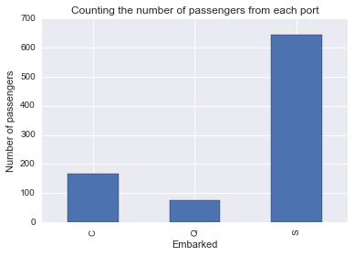

```python
ax = t_data.groupby('Embarked').size().plot(kind='bar')
ax.set_title('Counting the number of passengers from each port')
ax.set(ylabel = 'Number of passengers')
# Alternative command (with order differences): t_data["Embarked"].value_counts().plot(kind = "bar")
```

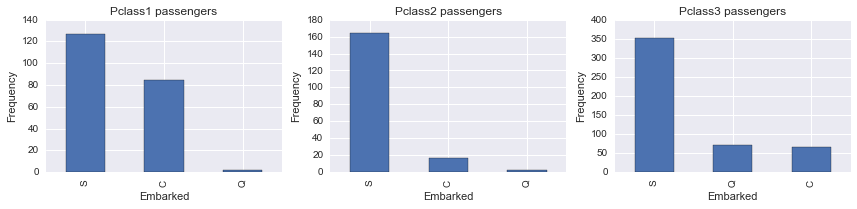

```python
# I draw the histogram of variable "Embarked", conditional on Class,

plt.figure(1, figsize=(12,3))                # default figure creation
ax1 = plt.subplot(1,3,1)                    # (number_of_rows, num_of_cols_, Plot_num)
ax1.set_title("Pclass1 passengers")
ax1.set(xlabel = "Embarked", ylabel = "Frequency")
t_data.loc[t_data["Pclass"] == 1, "Embarked"].value_counts().plot(kind = 'bar')

ax2 = plt.subplot(1,3,2)                    # the second subplot in the first figure
ax2.set_title("Pclass2 passengers")
ax2.set(xlabel = "Embarked", ylabel = "Frequency")
t_data.loc[t_data["Pclass"] == 2, "Embarked"].value_counts().plot.bar()

ax3 = plt.subplot(1,3,3)                    # the third subplot in the first figure
ax3.set_title("Pclass3 passengers")
ax3.set(xlabel = "Embarked", ylabel = "Frequency")
t_data.loc[t_data["Pclass"] == 3, "Embarked"].value_counts().plot.bar()
plt.tight_layout()
```

Most people were embarked at "S". I replace the missing values by the mode "S".

```python
t_data.loc[t_data["Embarked"].isnull(), "Embarked"] = "S"

# Alternative method:
# t_data["Embarked"] = np.where(t_data["Embarked"].isnull(), # condition check
#                               'S',                          # replaced value if check is true
#                               t_data["Embarked"])     # replaced value if check is false

# To check:  t_data[t_data["Embarked"].isnull()]

# for some reason, the following does not work:
# t_data.loc[t_data["Embarked"].isnull(), "Embarked"].fillna("S", inplace = True)
```

##### 2.2 Converting Sex to numeric value; Making children sex-independent.

It would be more reasonable to isolate kids from the original categories male and female.

```python
# check whether there are missing values by the unique() method
t_data["Sex"].unique()

# replace "female" with 1 and "male" with 0.
t_data.loc[t_data["Sex"] == "female", "Sex"] = 1
t_data.loc[t_data["Sex"] == "male", "Sex"] = 0

# assign 2 to kids belonging to the age group age_0_8, regardless of their gender.
t_data.loc[t_data["Age_groups"] == "age_0_8", "Sex"] = 2

# I create descriptive labels for each instance.
t_data["Survived_label"] = t_data.Survived.map({0: "Male", 1: "Female", 2: "Kids"})

# check.
t_data["Sex"].value_counts()
# t_data.sort_values(["Sex"], ascending = False)
```

```
0    545
1    288
2     58
Name: Sex, dtype: int64
```

##### 2.3 Family size and potentially related people

People who travel together can have diverse relationships:

1. They could come from the same family
2. People can travel together because they are friends or partners
3. A child needs to be looked after by someone if the parents are not arround
4. Rich people may have servants with them, etc.

The aim of this sub-section is to detect such relationships.

#### 2.3.1 Family size

I will define a quantitative variable "Family_size" which counts the number of members within a family.

I also define a qualitative variable "Family": 1 stands for having a family, 0 otherwise.

```python
# I define the family size.
t_data["Family_size"] = t_data["SibSp"] + t_data["Parch"]

# I also define a qualitative variable, which is equal to 1 when this person has a family, and 0 otherwise.
t_data["Family"] = np.where(t_data["Family_size"] >=1, 1, 0)
```

I use the following code to make a summary of percentage of each family size.

```python
(t_data["Family_size"].value_counts()/t_data["PassengerId"].count()) * 100
```

```
0     60.269360
1     18.069585
2     11.447811
3      3.254770
5      2.469136
4      1.683502
6      1.346801
10     0.785634
7      0.673401
Name: Family_size, dtype: float64
```

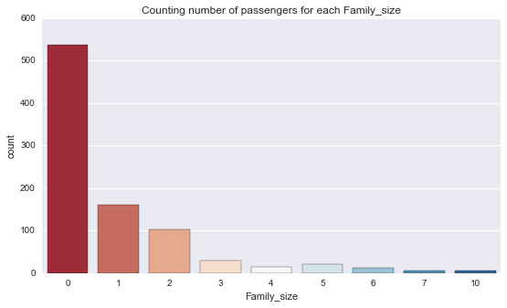

```python
# A plot can be made to visualize the above statistics.
plt.figure(1, figsize=(9,5))
ax=sns.countplot(x="Family_size", data=t_data, palette='RdBu');
ax.set(xlabel='Family_size', title='Counting number of passengers for each Family_size')
plt.show()
```

It appears that around 60% of people are of familiy size 0.

##### Is it indeed the case that they were travelling alone? The following subsection will give an answer.

#### 2.3.2 Ticket number

I manage to find that that people who share the same "Ticket" number are probably travelling together. I now show how I proceeded.

At the beginning, I had no exact clue on which direction to proceed. So I tried to first spot those people who are potentially servants. I heard that most servants are females. So I made some hypothesis on the universal characteristics of potential maids.

1. Maids must embark at the same port as the persons they look after.
2. Maids must be an adult, and not married
3. I make the big assumptioin that the ticket fare for the maids is identical with that of the family she travels with. (This is inspired by the study of subsection 2.2.0)

```python
# Based on my assumption, I group by ["Embarked", "Fare"].
# The person who this maid looks after may have a different prefix from her.

step1_df = t_data.groupby(["Embarked", "Fare"])\
.filter(lambda x: x[(x["prefix"]=="Miss") & (x["age_filled"]>=19) & (x["Family"]==0)].count()["prefix"]>0)
# Alternative: t_data.groupby(["Embarked", "Fare"]).filter(lambda x: sum(x["prefix"] == "Miss")>0)

# I sort the table by "Fare".
step2_df = step1_df.sort_values(["Embarked", "Fare"])
step2_df.groupby("Fare").filter(lambda x: len(x["PassengerId"])>1)
```

|  | PassengerId | Survived | Pclass | Sex | Age | SibSp | Parch | Ticket | Fare | Cabin | ... | prefix | Last_Name | First_Name | age_filled | Age_groups | Embarked_label | Passenger_class_label | Survived_label | Family_size | Family |
| --- | --- | --- | --- | --- | --- | --- | --- | --- | --- | --- | --- | --- | --- | --- | --- | --- | --- | --- | --- | --- | --- |
| 209 | 210 | 1 | 1 | 0 | 40.00 | 0 | 0 | 112277 | 31.0000 | A31 | ... | Mr | Blank | Henry | 40.00 | age_32_40 | Cherbourg | First Class | Female | 0 | 0 |
| 842 | 843 | 1 | 1 | 1 | 30.00 | 0 | 0 | 113798 | 31.0000 | NaN | ... | Miss | Serepeca | Augusta | 30.00 | age_24_32 | Cherbourg | First Class | Female | 0 | 0 |
| 309 | 310 | 1 | 1 | 1 | 30.00 | 0 | 0 | PC 17485 | 56.9292 | E36 | ... | Miss | Francatelli | Laura Mabel | 30.00 | age_24_32 | Cherbourg | First Class | Female | 0 | 0 |
| 599 | 600 | 1 | 1 | 0 | 49.00 | 1 | 0 | PC 17485 | 56.9292 | A20 | ... | Sir | Duff Gordon | Cosmo Edmund ("Mr Morgan") | 49.00 | age_48_56 | Cherbourg | First Class | Female | 1 | 1 |
| 310 | 311 | 1 | 1 | 1 | 24.00 | 0 | 0 | 11767 | 83.1583 | C54 | ... | Miss | Hays | Margaret Bechstein | 24.00 | age_16_24 | Cherbourg | First Class | Female | 0 | 0 |
| 835 | 836 | 1 | 1 | 1 | 39.00 | 1 | 1 | PC 17756 | 83.1583 | E49 | ... | Miss | Compton | Sara Rebecca | 39.00 | age_32_40 | Cherbourg | First Class | Female | 2 | 1 |
| 879 | 880 | 1 | 1 | 1 | 56.00 | 0 | 1 | 11767 | 83.1583 | C50 | ... | Mrs | Potter | Thomas Jr (Lily Alexenia Wilson) | 56.00 | age_48_56 | Cherbourg | First Class | Female | 1 | 1 |
| 537 | 538 | 1 | 1 | 1 | 30.00 | 0 | 0 | PC 17761 | 106.4250 | NaN | ... | Miss | LeRoy | Bertha | 30.00 | age_24_32 | Cherbourg | First Class | Female | 0 | 0 |
| 544 | 545 | 0 | 1 | 0 | 50.00 | 1 | 0 | PC 17761 | 106.4250 | C86 | ... | Mr | Douglas | Walter Donald | 50.00 | age_48_56 | Cherbourg | First Class | Male | 1 | 1 |
| 306 | 307 | 1 | 1 | 1 | NaN | 0 | 0 | 17421 | 110.8833 | NaN | ... | Miss | Fleming | Margaret | 21.00 | age_16_24 | Cherbourg | First Class | Female | 0 | 0 |
| 550 | 551 | 1 | 1 | 0 | 17.00 | 0 | 2 | 17421 | 110.8833 | C70 | ... | Mr | Thayer | John Borland Jr | 17.00 | age_16_24 | Cherbourg | First Class | Female | 2 | 1 |
| 581 | 582 | 1 | 1 | 1 | 39.00 | 1 | 1 | 17421 | 110.8833 | C68 | ... | Mrs | Thayer | John Borland (Marian Longstreth Morris) | 39.00 | age_32_40 | Cherbourg | First Class | Female | 2 | 1 |
| 698 | 699 | 0 | 1 | 0 | 49.00 | 1 | 1 | 17421 | 110.8833 | C68 | ... | Mr | Thayer | John Borland | 49.00 | age_48_56 | Cherbourg | First Class | Male | 2 | 1 |
| 319 | 320 | 1 | 1 | 1 | 40.00 | 1 | 1 | 16966 | 134.5000 | E34 | ... | Mrs | Spedden | Frederic Oakley (Margaretta Corning Stone) | 40.00 | age_32_40 | Cherbourg | First Class | Female | 2 | 1 |
| 337 | 338 | 1 | 1 | 1 | 41.00 | 0 | 0 | 16966 | 134.5000 | E40 | ... | Miss | Burns | Elizabeth Margaret | 41.00 | age_40_48 | Cherbourg | First Class | Female | 0 | 0 |
| 325 | 326 | 1 | 1 | 1 | 36.00 | 0 | 0 | PC 17760 | 135.6333 | C32 | ... | Miss | Young | Marie Grice | 36.00 | age_32_40 | Cherbourg | First Class | Female | 0 | 0 |
| 373 | 374 | 0 | 1 | 0 | 22.00 | 0 | 0 | PC 17760 | 135.6333 | NaN | ... | Mr | Ringhini | Sante | 22.00 | age_16_24 | Cherbourg | First Class | Male | 0 | 0 |
| 31 | 32 | 1 | 1 | 1 | NaN | 1 | 0 | PC 17569 | 146.5208 | B78 | ... | Mrs | Spencer | William Augustus (Marie Eugenie) | 35.00 | age_32_40 | Cherbourg | First Class | Female | 1 | 1 |
| 195 | 196 | 1 | 1 | 1 | 58.00 | 0 | 0 | PC 17569 | 146.5208 | B80 | ... | Miss | Lurette | Elise | 58.00 | age_56_64 | Cherbourg | First Class | Female | 0 | 0 |
| 380 | 381 | 1 | 1 | 1 | 42.00 | 0 | 0 | PC 17757 | 227.5250 | NaN | ... | Miss | Bidois | Rosalie | 42.00 | age_40_48 | Cherbourg | First Class | Female | 0 | 0 |
| 557 | 558 | 0 | 1 | 0 | NaN | 0 | 0 | PC 17757 | 227.5250 | NaN | ... | Mr | Robbins | Victor | 30.00 | age_24_32 | Cherbourg | First Class | Male | 0 | 0 |
| 700 | 701 | 1 | 1 | 1 | 18.00 | 1 | 0 | PC 17757 | 227.5250 | C62 C64 | ... | Mrs | Astor | John Jacob (Madeleine Talmadge Force) | 18.00 | age_16_24 | Cherbourg | First Class | Female | 1 | 1 |
| 716 | 717 | 1 | 1 | 1 | 38.00 | 0 | 0 | PC 17757 | 227.5250 | C45 | ... | Miss | Endres | Caroline Louise | 38.00 | age_32_40 | Cherbourg | First Class | Female | 0 | 0 |
| 258 | 259 | 1 | 1 | 1 | 35.00 | 0 | 0 | PC 17755 | 512.3292 | NaN | ... | Miss | Ward | Anna | 35.00 | age_32_40 | Cherbourg | First Class | Female | 0 | 0 |
| 679 | 680 | 1 | 1 | 0 | 36.00 | 0 | 1 | PC 17755 | 512.3292 | B51 B53 B55 | ... | Mr | Cardeza | Thomas Drake Martinez | 36.00 | age_32_40 | Cherbourg | First Class | Female | 1 | 1 |
| 737 | 738 | 1 | 1 | 0 | 35.00 | 0 | 0 | PC 17755 | 512.3292 | B101 | ... | Mr | Lesurer | Gustave J | 35.00 | age_32_40 | Cherbourg | First Class | Female | 0 | 0 |
| 156 | 157 | 1 | 3 | 1 | 16.00 | 0 | 0 | 35851 | 7.7333 | NaN | ... | Miss | Gilnagh | Katherine "Katie" | 16.00 | age_8_16 | Queenstown | Third Class | Female | 0 | 0 |
| 421 | 422 | 0 | 3 | 0 | 21.00 | 0 | 0 | A/5. 13032 | 7.7333 | NaN | ... | Mr | Charters | David | 21.00 | age_16_24 | Queenstown | Third Class | Male | 0 | 0 |
| 629 | 630 | 0 | 3 | 0 | NaN | 0 | 0 | 334912 | 7.7333 | NaN | ... | Mr | O'Connell | Patrick D | 30.00 | age_24_32 | Queenstown | Third Class | Male | 0 | 0 |
| 697 | 698 | 1 | 3 | 1 | NaN | 0 | 0 | 35852 | 7.7333 | NaN | ... | Miss | Mullens | Katherine "Katie" | 21.00 | age_16_24 | Queenstown | Third Class | Female | 0 | 0 |
| ... | ... | ... | ... | ... | ... | ... | ... | ... | ... | ... | ... | ... | ... | ... | ... | ... | ... | ... | ... | ... | ... |
| 630 | 631 | 1 | 1 | 0 | 80.00 | 0 | 0 | 27042 | 30.0000 | A23 | ... | Mr | Barkworth | Algernon Henry Wilson | 80.00 | age_72_80 | Southampton | First Class | Female | 0 | 0 |
| 740 | 741 | 1 | 1 | 0 | NaN | 0 | 0 | 16988 | 30.0000 | D45 | ... | Mr | Hawksford | Walter James | 30.00 | age_24_32 | Southampton | First Class | Female | 0 | 0 |
| 782 | 783 | 0 | 1 | 0 | 29.00 | 0 | 0 | 113501 | 30.0000 | D6 | ... | Mr | Long | Milton Clyde | 29.00 | age_24_32 | Southampton | First Class | Male | 0 | 0 |
| 887 | 888 | 1 | 1 | 1 | 19.00 | 0 | 0 | 112053 | 30.0000 | B42 | ... | Miss | Graham | Margaret Edith | 19.00 | age_16_24 | Southampton | First Class | Female | 0 | 0 |
| 596 | 597 | 1 | 2 | 1 | NaN | 0 | 0 | 248727 | 33.0000 | NaN | ... | Miss | Leitch | Jessie Wills | 21.00 | age_16_24 | Southampton | Second Class | Female | 0 | 0 |
| 720 | 721 | 1 | 2 | 2 | 6.00 | 0 | 1 | 248727 | 33.0000 | NaN | ... | Miss | Harper | Annie Jessie "Nina" | 6.00 | age_0_8 | Southampton | Second Class | Female | 1 | 1 |
| 848 | 849 | 0 | 2 | 0 | 28.00 | 0 | 1 | 248727 | 33.0000 | NaN | ... | Rev | Harper | John | 28.00 | age_24_32 | Southampton | Second Class | Male | 1 | 1 |
| 275 | 276 | 1 | 1 | 1 | 63.00 | 1 | 0 | 13502 | 77.9583 | D7 | ... | Miss | Andrews | Kornelia Theodosia | 63.00 | age_56_64 | Southampton | First Class | Female | 1 | 1 |
| 627 | 628 | 1 | 1 | 1 | 21.00 | 0 | 0 | 13502 | 77.9583 | D9 | ... | Miss | Longley | Gretchen Fiske | 21.00 | age_16_24 | Southampton | First Class | Female | 0 | 0 |
| 765 | 766 | 1 | 1 | 1 | 51.00 | 1 | 0 | 13502 | 77.9583 | D11 | ... | Mrs | Hogeboom | John C (Anna Andrews) | 51.00 | age_48_56 | Southampton | First Class | Female | 1 | 1 |
| 290 | 291 | 1 | 1 | 1 | 26.00 | 0 | 0 | 19877 | 78.8500 | NaN | ... | Miss | Barber | Ellen "Nellie" | 26.00 | age_24_32 | Southampton | First Class | Female | 0 | 0 |
| 741 | 742 | 0 | 1 | 0 | 36.00 | 1 | 0 | 19877 | 78.8500 | C46 | ... | Mr | Cavendish | Tyrell William | 36.00 | age_32_40 | Southampton | First Class | Male | 1 | 1 |
| 61 | 62 | 1 | 1 | 1 | 38.00 | 0 | 0 | 113572 | 80.0000 | B28 | ... | Miss | Icard | Amelie | 38.00 | age_32_40 | NaN | First Class | Female | 0 | 0 |
| 829 | 830 | 1 | 1 | 1 | 62.00 | 0 | 0 | 113572 | 80.0000 | B28 | ... | Mrs | Stone | George Nelson (Martha Evelyn) | 62.00 | age_56_64 | NaN | First Class | Female | 0 | 0 |
| 257 | 258 | 1 | 1 | 1 | 30.00 | 0 | 0 | 110152 | 86.5000 | B77 | ... | Miss | Cherry | Gladys | 30.00 | age_24_32 | Southampton | First Class | Female | 0 | 0 |
| 504 | 505 | 1 | 1 | 1 | 16.00 | 0 | 0 | 110152 | 86.5000 | B79 | ... | Miss | Maioni | Roberta | 16.00 | age_8_16 | Southampton | First Class | Female | 0 | 0 |
| 759 | 760 | 1 | 1 | 1 | 33.00 | 0 | 0 | 110152 | 86.5000 | B77 | ... | the Countess | Rothes | of (Lucy Noel Martha Dyer-Edwards) | 33.00 | age_32_40 | Southampton | First Class | Female | 0 | 0 |
| 520 | 521 | 1 | 1 | 1 | 30.00 | 0 | 0 | 12749 | 93.5000 | B73 | ... | Miss | Perreault | Anne | 30.00 | age_24_32 | Southampton | First Class | Female | 0 | 0 |
| 820 | 821 | 1 | 1 | 1 | 52.00 | 1 | 1 | 12749 | 93.5000 | B69 | ... | Mrs | Hays | Charles Melville (Clara Jennings Gregg) | 52.00 | age_48_56 | Southampton | First Class | Female | 2 | 1 |
| 269 | 270 | 1 | 1 | 1 | 35.00 | 0 | 0 | PC 17760 | 135.6333 | C99 | ... | Miss | Bissette | Amelia | 35.00 | age_32_40 | Southampton | First Class | Female | 0 | 0 |
| 297 | 298 | 0 | 1 | 2 | 2.00 | 1 | 2 | 113781 | 151.5500 | C22 C26 | ... | Miss | Allison | Helen Loraine | 2.00 | age_0_8 | Southampton | First Class | Male | 3 | 1 |
| 305 | 306 | 1 | 1 | 2 | 0.92 | 1 | 2 | 113781 | 151.5500 | C22 C26 | ... | Master | Allison | Hudson Trevor | 0.92 | age_0_8 | Southampton | First Class | Female | 3 | 1 |
| 498 | 499 | 0 | 1 | 1 | 25.00 | 1 | 2 | 113781 | 151.5500 | C22 C26 | ... | Mrs | Allison | Hudson J C (Bessie Waldo Daniels) | 25.00 | age_24_32 | Southampton | First Class | Male | 3 | 1 |
| 708 | 709 | 1 | 1 | 1 | 22.00 | 0 | 0 | 113781 | 151.5500 | NaN | ... | Miss | Cleaver | Alice | 22.00 | age_16_24 | Southampton | First Class | Female | 0 | 0 |
| 268 | 269 | 1 | 1 | 1 | 58.00 | 0 | 1 | PC 17582 | 153.4625 | C125 | ... | Mrs | Graham | William Thompson (Edith Junkins) | 58.00 | age_56_64 | Southampton | First Class | Female | 1 | 1 |
| 332 | 333 | 0 | 1 | 0 | 38.00 | 0 | 1 | PC 17582 | 153.4625 | C91 | ... | Mr | Graham | George Edward | 38.00 | age_32_40 | Southampton | First Class | Male | 1 | 1 |
| 609 | 610 | 1 | 1 | 1 | 40.00 | 0 | 0 | PC 17582 | 153.4625 | C125 | ... | Miss | Shutes | Elizabeth W | 40.00 | age_32_40 | Southampton | First Class | Female | 0 | 0 |
| 689 | 690 | 1 | 1 | 1 | 15.00 | 0 | 1 | 24160 | 211.3375 | B5 | ... | Miss | Madill | Georgette Alexandra | 15.00 | age_8_16 | Southampton | First Class | Female | 1 | 1 |
| 730 | 731 | 1 | 1 | 1 | 29.00 | 0 | 0 | 24160 | 211.3375 | B5 | ... | Miss | Allen | Elisabeth Walton | 29.00 | age_24_32 | Southampton | First Class | Female | 0 | 0 |
| 779 | 780 | 1 | 1 | 1 | 43.00 | 0 | 1 | 24160 | 211.3375 | B3 | ... | Mrs | Robert | Edward Scott (Elisabeth Walton McMillan) | 43.00 | age_40_48 | Southampton | First Class | Female | 1 | 1 |

385 rows × 21 columns

#### From the table above, I notice that there are a lot of identical "Ticket" number. And people who have the same fare seem to share the same ticket number quite often, which implies that these people might have bought the ticket together.

This leads me to think that ticket number may be a better trait for checking whether people are travelling together.

I now proceed through this direction: using ticket number to spot people who travel together.

```python
# I run the following code to group data by ticket number.
step_together_df = t_data.groupby(["Ticket"]).\
filter(lambda x: (x["Fare"].nunique()==1) & (x["Fare"].count()>1)).sort_values(["Ticket"])
# Alternative(not working): t_data.groupby(["Ticket"]).filter(lambda x: x["Fare"].value_counts().iloc[0]>1).sort_values(["Ticket"])
step_together_df
```

|  | PassengerId | Survived | Pclass | Sex | Age | SibSp | Parch | Ticket | Fare | Cabin | ... | prefix | Last_Name | First_Name | age_filled | Age_groups | Embarked_label | Passenger_class_label | Survived_label | Family_size | Family |
| --- | --- | --- | --- | --- | --- | --- | --- | --- | --- | --- | --- | --- | --- | --- | --- | --- | --- | --- | --- | --- | --- |
| 257 | 258 | 1 | 1 | 1 | 30.00 | 0 | 0 | 110152 | 86.5000 | B77 | ... | Miss | Cherry | Gladys | 30.00 | age_24_32 | Southampton | First Class | Female | 0 | 0 |
| 759 | 760 | 1 | 1 | 1 | 33.00 | 0 | 0 | 110152 | 86.5000 | B77 | ... | the Countess | Rothes | of (Lucy Noel Martha Dyer-Edwards) | 33.00 | age_32_40 | Southampton | First Class | Female | 0 | 0 |
| 504 | 505 | 1 | 1 | 1 | 16.00 | 0 | 0 | 110152 | 86.5000 | B79 | ... | Miss | Maioni | Roberta | 16.00 | age_8_16 | Southampton | First Class | Female | 0 | 0 |
| 262 | 263 | 0 | 1 | 0 | 52.00 | 1 | 1 | 110413 | 79.6500 | E67 | ... | Mr | Taussig | Emil | 52.00 | age_48_56 | Southampton | First Class | Male | 2 | 1 |
| 558 | 559 | 1 | 1 | 1 | 39.00 | 1 | 1 | 110413 | 79.6500 | E67 | ... | Mrs | Taussig | Emil (Tillie Mandelbaum) | 39.00 | age_32_40 | Southampton | First Class | Female | 2 | 1 |
| 585 | 586 | 1 | 1 | 1 | 18.00 | 0 | 2 | 110413 | 79.6500 | E68 | ... | Miss | Taussig | Ruth | 18.00 | age_16_24 | Southampton | First Class | Female | 2 | 1 |
| 110 | 111 | 0 | 1 | 0 | 47.00 | 0 | 0 | 110465 | 52.0000 | C110 | ... | Mr | Porter | Walter Chamberlain | 47.00 | age_40_48 | Southampton | First Class | Male | 0 | 0 |
| 475 | 476 | 0 | 1 | 0 | NaN | 0 | 0 | 110465 | 52.0000 | A14 | ... | Mr | Clifford | George Quincy | 30.00 | age_24_32 | Southampton | First Class | Male | 0 | 0 |
| 523 | 524 | 1 | 1 | 1 | 44.00 | 0 | 1 | 111361 | 57.9792 | B18 | ... | Mrs | Hippach | Louis Albert (Ida Sophia Fischer) | 44.00 | age_40_48 | Cherbourg | First Class | Female | 1 | 1 |
| 329 | 330 | 1 | 1 | 1 | 16.00 | 0 | 1 | 111361 | 57.9792 | B18 | ... | Miss | Hippach | Jean Gertrude | 16.00 | age_8_16 | Cherbourg | First Class | Female | 1 | 1 |
| 166 | 167 | 1 | 1 | 1 | NaN | 0 | 1 | 113505 | 55.0000 | E33 | ... | Mrs | Chibnall | (Edith Martha Bowerman) | 35.00 | age_32_40 | Southampton | First Class | Female | 1 | 1 |
| 356 | 357 | 1 | 1 | 1 | 22.00 | 0 | 1 | 113505 | 55.0000 | E33 | ... | Miss | Bowerman | Elsie Edith | 22.00 | age_16_24 | Southampton | First Class | Female | 1 | 1 |
| 829 | 830 | 1 | 1 | 1 | 62.00 | 0 | 0 | 113572 | 80.0000 | B28 | ... | Mrs | Stone | George Nelson (Martha Evelyn) | 62.00 | age_56_64 | NaN | First Class | Female | 0 | 0 |
| 61 | 62 | 1 | 1 | 1 | 38.00 | 0 | 0 | 113572 | 80.0000 | B28 | ... | Miss | Icard | Amelie | 38.00 | age_32_40 | NaN | First Class | Female | 0 | 0 |
| 390 | 391 | 1 | 1 | 0 | 36.00 | 1 | 2 | 113760 | 120.0000 | B96 B98 | ... | Mr | Carter | William Ernest | 36.00 | age_32_40 | Southampton | First Class | Female | 3 | 1 |
| 802 | 803 | 1 | 1 | 0 | 11.00 | 1 | 2 | 113760 | 120.0000 | B96 B98 | ... | Master | Carter | William Thornton II | 11.00 | age_8_16 | Southampton | First Class | Female | 3 | 1 |
| 435 | 436 | 1 | 1 | 1 | 14.00 | 1 | 2 | 113760 | 120.0000 | B96 B98 | ... | Miss | Carter | Lucile Polk | 14.00 | age_8_16 | Southampton | First Class | Female | 3 | 1 |
| 763 | 764 | 1 | 1 | 1 | 36.00 | 1 | 2 | 113760 | 120.0000 | B96 B98 | ... | Mrs | Carter | William Ernest (Lucile Polk) | 36.00 | age_32_40 | Southampton | First Class | Female | 3 | 1 |
| 151 | 152 | 1 | 1 | 1 | 22.00 | 1 | 0 | 113776 | 66.6000 | C2 | ... | Mrs | Pears | Thomas (Edith Wearne) | 22.00 | age_16_24 | Southampton | First Class | Female | 1 | 1 |
| 336 | 337 | 0 | 1 | 0 | 29.00 | 1 | 0 | 113776 | 66.6000 | C2 | ... | Mr | Pears | Thomas Clinton | 29.00 | age_24_32 | Southampton | First Class | Male | 1 | 1 |
| 498 | 499 | 0 | 1 | 1 | 25.00 | 1 | 2 | 113781 | 151.5500 | C22 C26 | ... | Mrs | Allison | Hudson J C (Bessie Waldo Daniels) | 25.00 | age_24_32 | Southampton | First Class | Male | 3 | 1 |
| 708 | 709 | 1 | 1 | 1 | 22.00 | 0 | 0 | 113781 | 151.5500 | NaN | ... | Miss | Cleaver | Alice | 22.00 | age_16_24 | Southampton | First Class | Female | 0 | 0 |
| 297 | 298 | 0 | 1 | 2 | 2.00 | 1 | 2 | 113781 | 151.5500 | C22 C26 | ... | Miss | Allison | Helen Loraine | 2.00 | age_0_8 | Southampton | First Class | Male | 3 | 1 |
| 305 | 306 | 1 | 1 | 2 | 0.92 | 1 | 2 | 113781 | 151.5500 | C22 C26 | ... | Master | Allison | Hudson Trevor | 0.92 | age_0_8 | Southampton | First Class | Female | 3 | 1 |
| 383 | 384 | 1 | 1 | 1 | 35.00 | 1 | 0 | 113789 | 52.0000 | NaN | ... | Mrs | Holverson | Alexander Oskar (Mary Aline Towner) | 35.00 | age_32_40 | Southampton | First Class | Female | 1 | 1 |
| 35 | 36 | 0 | 1 | 0 | 42.00 | 1 | 0 | 113789 | 52.0000 | NaN | ... | Mr | Holverson | Alexander Oskar | 42.00 | age_40_48 | Southampton | First Class | Male | 1 | 1 |
| 270 | 271 | 0 | 1 | 0 | NaN | 0 | 0 | 113798 | 31.0000 | NaN | ... | Mr | Cairns | Alexander | 30.00 | age_24_32 | Southampton | First Class | Male | 0 | 0 |
| 842 | 843 | 1 | 1 | 1 | 30.00 | 0 | 0 | 113798 | 31.0000 | NaN | ... | Miss | Serepeca | Augusta | 30.00 | age_24_32 | Cherbourg | First Class | Female | 0 | 0 |
| 3 | 4 | 1 | 1 | 1 | 35.00 | 1 | 0 | 113803 | 53.1000 | C123 | ... | Mrs | Futrelle | Jacques Heath (Lily May Peel) | 35.00 | age_32_40 | Southampton | First Class | Female | 1 | 1 |
| 137 | 138 | 0 | 1 | 0 | 37.00 | 1 | 0 | 113803 | 53.1000 | C123 | ... | Mr | Futrelle | Jacques Heath | 37.00 | age_32_40 | Southampton | First Class | Male | 1 | 1 |
| ... | ... | ... | ... | ... | ... | ... | ... | ... | ... | ... | ... | ... | ... | ... | ... | ... | ... | ... | ... | ... | ... |
| 307 | 308 | 1 | 1 | 1 | 17.00 | 1 | 0 | PC 17758 | 108.9000 | C65 | ... | Mrs | Penasco y Castellana | Victor de Satode (Maria Josefa Perez de Soto y... | 17.00 | age_16_24 | Cherbourg | First Class | Female | 1 | 1 |
| 269 | 270 | 1 | 1 | 1 | 35.00 | 0 | 0 | PC 17760 | 135.6333 | C99 | ... | Miss | Bissette | Amelia | 35.00 | age_32_40 | Southampton | First Class | Female | 0 | 0 |
| 325 | 326 | 1 | 1 | 1 | 36.00 | 0 | 0 | PC 17760 | 135.6333 | C32 | ... | Miss | Young | Marie Grice | 36.00 | age_32_40 | Cherbourg | First Class | Female | 0 | 0 |
| 373 | 374 | 0 | 1 | 0 | 22.00 | 0 | 0 | PC 17760 | 135.6333 | NaN | ... | Mr | Ringhini | Sante | 22.00 | age_16_24 | Cherbourg | First Class | Male | 0 | 0 |
| 537 | 538 | 1 | 1 | 1 | 30.00 | 0 | 0 | PC 17761 | 106.4250 | NaN | ... | Miss | LeRoy | Bertha | 30.00 | age_24_32 | Cherbourg | First Class | Female | 0 | 0 |
| 544 | 545 | 0 | 1 | 0 | 50.00 | 1 | 0 | PC 17761 | 106.4250 | C86 | ... | Mr | Douglas | Walter Donald | 50.00 | age_48_56 | Cherbourg | First Class | Male | 1 | 1 |
| 394 | 395 | 1 | 3 | 1 | 24.00 | 0 | 2 | PP 9549 | 16.7000 | G6 | ... | Mrs | Sandstrom | Hjalmar (Agnes Charlotta Bengtsson) | 24.00 | age_16_24 | Southampton | Third Class | Female | 2 | 1 |
| 10 | 11 | 1 | 3 | 2 | 4.00 | 1 | 1 | PP 9549 | 16.7000 | G6 | ... | Miss | Sandstrom | Marguerite Rut | 4.00 | age_0_8 | Southampton | Third Class | Female | 2 | 1 |
| 817 | 818 | 0 | 2 | 0 | 31.00 | 1 | 1 | S.C./PARIS 2079 | 37.0042 | NaN | ... | Mr | Mallet | Albert | 31.00 | age_24_32 | Cherbourg | Second Class | Male | 2 | 1 |
| 827 | 828 | 1 | 2 | 2 | 1.00 | 0 | 2 | S.C./PARIS 2079 | 37.0042 | NaN | ... | Master | Mallet | Andre | 1.00 | age_0_8 | Cherbourg | Second Class | Female | 2 | 1 |
| 841 | 842 | 0 | 2 | 0 | 16.00 | 0 | 0 | S.O./P.P. 3 | 10.5000 | NaN | ... | Mr | Mudd | Thomas Charles | 16.00 | age_8_16 | Southampton | Second Class | Male | 0 | 0 |
| 772 | 773 | 0 | 2 | 1 | 57.00 | 0 | 0 | S.O./P.P. 3 | 10.5000 | E77 | ... | Mrs | Mack | (Mary) | 57.00 | age_56_64 | Southampton | Second Class | Male | 0 | 0 |
| 72 | 73 | 0 | 2 | 0 | 21.00 | 0 | 0 | S.O.C. 14879 | 73.5000 | NaN | ... | Mr | Hood | Ambrose Jr | 21.00 | age_16_24 | Southampton | Second Class | Male | 0 | 0 |
| 665 | 666 | 0 | 2 | 0 | 32.00 | 2 | 0 | S.O.C. 14879 | 73.5000 | NaN | ... | Mr | Hickman | Lewis | 32.00 | age_24_32 | Southampton | Second Class | Male | 2 | 1 |
| 120 | 121 | 0 | 2 | 0 | 21.00 | 2 | 0 | S.O.C. 14879 | 73.5000 | NaN | ... | Mr | Hickman | Stanley George | 21.00 | age_16_24 | Southampton | Second Class | Male | 2 | 1 |
| 385 | 386 | 0 | 2 | 0 | 18.00 | 0 | 0 | S.O.C. 14879 | 73.5000 | NaN | ... | Mr | Davies | Charles Henry | 18.00 | age_16_24 | Southampton | Second Class | Male | 0 | 0 |
| 655 | 656 | 0 | 2 | 0 | 24.00 | 2 | 0 | S.O.C. 14879 | 73.5000 | NaN | ... | Mr | Hickman | Leonard Mark | 24.00 | age_16_24 | Southampton | Second Class | Male | 2 | 1 |
| 685 | 686 | 0 | 2 | 0 | 25.00 | 1 | 2 | SC/Paris 2123 | 41.5792 | NaN | ... | Mr | Laroche | Joseph Philippe Lemercier | 25.00 | age_24_32 | Cherbourg | Second Class | Male | 3 | 1 |
| 43 | 44 | 1 | 2 | 2 | 3.00 | 1 | 2 | SC/Paris 2123 | 41.5792 | NaN | ... | Miss | Laroche | Simonne Marie Anne Andree | 3.00 | age_0_8 | Cherbourg | Second Class | Female | 3 | 1 |
| 608 | 609 | 1 | 2 | 1 | 22.00 | 1 | 2 | SC/Paris 2123 | 41.5792 | NaN | ... | Mrs | Laroche | Joseph (Juliette Marie Louise Lafargue) | 22.00 | age_16_24 | Cherbourg | Second Class | Female | 3 | 1 |
| 142 | 143 | 1 | 3 | 1 | 24.00 | 1 | 0 | STON/O2. 3101279 | 15.8500 | NaN | ... | Mrs | Hakkarainen | Pekka Pietari (Elin Matilda Dolck) | 24.00 | age_16_24 | Southampton | Third Class | Female | 1 | 1 |
| 403 | 404 | 0 | 3 | 0 | 28.00 | 1 | 0 | STON/O2. 3101279 | 15.8500 | NaN | ... | Mr | Hakkarainen | Pekka Pietari | 28.00 | age_24_32 | Southampton | Third Class | Male | 1 | 1 |
| 783 | 784 | 0 | 3 | 0 | NaN | 1 | 2 | W./C. 6607 | 23.4500 | NaN | ... | Mr | Johnston | Andrew G | 30.00 | age_24_32 | Southampton | Third Class | Male | 3 | 1 |
| 888 | 889 | 0 | 3 | 1 | NaN | 1 | 2 | W./C. 6607 | 23.4500 | NaN | ... | Miss | Johnston | Catherine Helen "Carrie" | 21.00 | age_16_24 | Southampton | Third Class | Male | 3 | 1 |
| 436 | 437 | 0 | 3 | 1 | 21.00 | 2 | 2 | W./C. 6608 | 34.3750 | NaN | ... | Miss | Ford | Doolina Margaret "Daisy" | 21.00 | age_16_24 | Southampton | Third Class | Male | 4 | 1 |
| 736 | 737 | 0 | 3 | 1 | 48.00 | 1 | 3 | W./C. 6608 | 34.3750 | NaN | ... | Mrs | Ford | Edward (Margaret Ann Watson) | 48.00 | age_40_48 | Southampton | Third Class | Male | 4 | 1 |
| 86 | 87 | 0 | 3 | 0 | 16.00 | 1 | 3 | W./C. 6608 | 34.3750 | NaN | ... | Mr | Ford | William Neal | 16.00 | age_8_16 | Southampton | Third Class | Male | 4 | 1 |
| 147 | 148 | 0 | 3 | 1 | 9.00 | 2 | 2 | W./C. 6608 | 34.3750 | NaN | ... | Miss | Ford | Robina Maggie "Ruby" | 9.00 | age_8_16 | Southampton | Third Class | Male | 4 | 1 |
| 540 | 541 | 1 | 1 | 1 | 36.00 | 0 | 2 | WE/P 5735 | 71.0000 | B22 | ... | Miss | Crosby | Harriet R | 36.00 | age_32_40 | Southampton | First Class | Female | 2 | 1 |
| 745 | 746 | 0 | 1 | 0 | 70.00 | 1 | 1 | WE/P 5735 | 71.0000 | B22 | ... | Capt | Crosby | Edward Gifford | 70.00 | age_64_72 | Southampton | First Class | Male | 2 | 1 |

342 rows × 21 columns

Let us have a look at several records. The first 3 observations suggest that there are two misses who serve as maids for the Countess.We are in the right direction.

#### It seems that people who have the same ticket number not only share the same fare, but probably also similar cabins. I now do the following check.

```python
# I want to have a look when ticket number is the same, whether the fare is different.

t_data.groupby(["Ticket"]).\
filter(lambda x: (x["Fare"].nunique()>1)).sort_values(["Ticket"])
```

|  | PassengerId | Survived | Pclass | Sex | Age | SibSp | Parch | Ticket | Fare | Cabin | ... | prefix | Last_Name | First_Name | age_filled | Age_groups | Embarked_label | Passenger_class_label | Survived_label | Family_size | Family |
| --- | --- | --- | --- | --- | --- | --- | --- | --- | --- | --- | --- | --- | --- | --- | --- | --- | --- | --- | --- | --- | --- |
| 138 | 139 | 0 | 3 | 0 | 16.0 | 0 | 0 | 7534 | 9.2167 | NaN | ... | Mr | Osen | Olaf Elon | 16.0 | age_8_16 | Southampton | Third Class | Male | 0 | 0 |
| 876 | 877 | 0 | 3 | 0 | 20.0 | 0 | 0 | 7534 | 9.8458 | NaN | ... | Mr | Gustafsson | Alfred Ossian | 20.0 | age_16_24 | Southampton | Third Class | Male | 0 | 0 |

2 rows × 21 columns

There is only 1 (Ticket) instance where the fare is different when the ticket number is identical. This suggests ticket number can be a good indicator. For the exception above, I will still consider them as travelling together.

```python
# I now use Ticket as an instrument to create another categorical variable travelling_together.
# When a ticket number is shared by more than 1 person, travelling_together will be assigned value 1.
# Otherwise, travelling_together will be assigned value 0.

def check_together(a_string):
    if a_string in step_together_df["Ticket"].unique():
        return 1
    else:
        return 0
t_data["Together"] = t_data["Ticket"].apply(check_together)
```

##### It is important to remark that this variable "Together" is defined independently of the variable "Family". The variable "Family" is defined from the perspective of the variable "Family_size". The variable "Together" is defined from the perspective of the variable "Ticket".

My ultimate objective is to have a more comprehensive variable capturing whether people are travelling together.

It is natural to check the following two cases which appear to be contradictory to my initiative:

1. People who have family but have different ticket: (t_data["Together"] == 0) & (t_data["Family"] == 1)
2. People who have no family but have identical ticket: (t_data["Together"] == 1) & (t_data["Family"] == 0)

```python
# People who have family but have different ticket number:
# The following code shows there are 85 such observations.
len(t_data[(t_data["Together"]==0) & (t_data["Family"]==1)].sort_values(["Ticket"]))

# A brief view:
t_data[(t_data["Together"]==0) & (t_data["Family"]==1)].sort_values(["Ticket"]).head(6)
```

|  | PassengerId | Survived | Pclass | Sex | Age | SibSp | Parch | Ticket | Fare | Cabin | ... | Last_Name | First_Name | age_filled | Age_groups | Embarked_label | Passenger_class_label | Survived_label | Family_size | Family | Together |
| --- | --- | --- | --- | --- | --- | --- | --- | --- | --- | --- | --- | --- | --- | --- | --- | --- | --- | --- | --- | --- | --- |
| 366 | 367 | 1 | 1 | 1 | 60.0 | 1 | 0 | 110813 | 75.2500 | D37 | ... | Warren | Frank Manley (Anna Sophia Atkinson) | 60.0 | age_56_64 | Cherbourg | First Class | Female | 1 | 1 | 0 |
| 377 | 378 | 0 | 1 | 0 | 27.0 | 0 | 2 | 113503 | 211.5000 | C82 | ... | Widener | Harry Elkins | 27.0 | age_24_32 | Cherbourg | First Class | Male | 2 | 1 | 0 |
| 54 | 55 | 0 | 1 | 0 | 65.0 | 0 | 1 | 113509 | 61.9792 | B30 | ... | Ostby | Engelhart Cornelius | 65.0 | age_64_72 | Cherbourg | First Class | Male | 1 | 1 | 0 |
| 748 | 749 | 0 | 1 | 0 | 19.0 | 1 | 0 | 113773 | 53.1000 | D30 | ... | Marvin | Daniel Warner | 19.0 | age_16_24 | Southampton | First Class | Male | 1 | 1 | 0 |
| 136 | 137 | 1 | 1 | 1 | 19.0 | 0 | 2 | 11752 | 26.2833 | D47 | ... | Newsom | Helen Monypeny | 19.0 | age_16_24 | Southampton | First Class | Female | 2 | 1 | 0 |
| 621 | 622 | 1 | 1 | 0 | 42.0 | 1 | 0 | 11753 | 52.5542 | D19 | ... | Kimball | Edwin Nelson Jr | 42.0 | age_40_48 | Southampton | First Class | Female | 1 | 1 | 0 |

6 rows × 22 columns

```python
# People who have no family but have identical ticket number:
# The following code shows there are 73 such observations.
len(t_data[(t_data["Together"]==1) & (t_data["Family"]==0)])

# A brief view:
t_data[(t_data["Together"]==1) & (t_data["Family"]==0)].head()
```

|  | PassengerId | Survived | Pclass | Sex | Age | SibSp | Parch | Ticket | Fare | Cabin | ... | Last_Name | First_Name | age_filled | Age_groups | Embarked_label | Passenger_class_label | Survived_label | Family_size | Family | Together |
| --- | --- | --- | --- | --- | --- | --- | --- | --- | --- | --- | --- | --- | --- | --- | --- | --- | --- | --- | --- | --- | --- |
| 20 | 21 | 0 | 2 | 0 | 35.0 | 0 | 0 | 239865 | 26.0000 | NaN | ... | Fynney | Joseph J | 35.0 | age_32_40 | Southampton | Second Class | Male | 0 | 0 | 1 |
| 61 | 62 | 1 | 1 | 1 | 38.0 | 0 | 0 | 113572 | 80.0000 | B28 | ... | Icard | Amelie | 38.0 | age_32_40 | NaN | First Class | Female | 0 | 0 | 1 |
| 72 | 73 | 0 | 2 | 0 | 21.0 | 0 | 0 | S.O.C. 14879 | 73.5000 | NaN | ... | Hood | Ambrose Jr | 21.0 | age_16_24 | Southampton | Second Class | Male | 0 | 0 | 1 |
| 74 | 75 | 1 | 3 | 0 | 32.0 | 0 | 0 | 1601 | 56.4958 | NaN | ... | Bing | Lee | 32.0 | age_24_32 | Southampton | Third Class | Female | 0 | 0 | 1 |
| 79 | 80 | 1 | 3 | 1 | 30.0 | 0 | 0 | 364516 | 12.4750 | NaN | ... | Dowdell | Elizabeth | 30.0 | age_24_32 | Southampton | Third Class | Female | 0 | 0 | 1 |

5 rows × 22 columns

```python
# I also sort the dataframe by age.
t_data.loc[t_data["Together"]==0].sort_values(["Age"], ascending = True).head(10)
```

|  | PassengerId | Survived | Pclass | Sex | Age | SibSp | Parch | Ticket | Fare | Cabin | ... | Last_Name | First_Name | age_filled | Age_groups | Embarked_label | Passenger_class_label | Survived_label | Family_size | Family | Together |
| --- | --- | --- | --- | --- | --- | --- | --- | --- | --- | --- | --- | --- | --- | --- | --- | --- | --- | --- | --- | --- | --- |
| 803 | 804 | 1 | 3 | 2 | 0.42 | 0 | 1 | 2625 | 8.5167 | NaN | ... | Thomas | Assad Alexander | 0.42 | age_0_8 | Cherbourg | Third Class | Female | 1 | 1 | 0 |
| 479 | 480 | 1 | 3 | 2 | 2.00 | 0 | 1 | 3101298 | 12.2875 | NaN | ... | Hirvonen | Hildur E | 2.00 | age_0_8 | Southampton | Third Class | Female | 1 | 1 | 0 |
| 445 | 446 | 1 | 1 | 2 | 4.00 | 0 | 2 | 33638 | 81.8583 | A34 | ... | Dodge | Washington | 4.00 | age_0_8 | Southampton | First Class | Female | 2 | 1 | 0 |
| 184 | 185 | 1 | 3 | 2 | 4.00 | 0 | 2 | 315153 | 22.0250 | NaN | ... | Kink-Heilmann | Luise Gretchen | 4.00 | age_0_8 | Southampton | Third Class | Female | 2 | 1 | 0 |
| 750 | 751 | 1 | 2 | 2 | 4.00 | 1 | 1 | 29103 | 23.0000 | NaN | ... | Wells | Joan | 4.00 | age_0_8 | Southampton | Second Class | Female | 2 | 1 | 0 |
| 691 | 692 | 1 | 3 | 2 | 4.00 | 0 | 1 | 349256 | 13.4167 | NaN | ... | Karun | Manca | 4.00 | age_0_8 | Cherbourg | Third Class | Female | 1 | 1 | 0 |
| 780 | 781 | 1 | 3 | 1 | 13.00 | 0 | 0 | 2687 | 7.2292 | NaN | ... | Ayoub | Banoura | 13.00 | age_8_16 | Cherbourg | Third Class | Female | 0 | 0 | 0 |
| 14 | 15 | 0 | 3 | 1 | 14.00 | 0 | 0 | 350406 | 7.8542 | NaN | ... | Vestrom | Hulda Amanda Adolfina | 14.00 | age_8_16 | Southampton | Third Class | Male | 0 | 0 | 0 |
| 352 | 353 | 0 | 3 | 0 | 15.00 | 1 | 1 | 2695 | 7.2292 | NaN | ... | Elias | Tannous | 15.00 | age_8_16 | Cherbourg | Third Class | Male | 2 | 1 | 0 |
| 22 | 23 | 1 | 3 | 1 | 15.00 | 0 | 0 | 330923 | 8.0292 | NaN | ... | McGowan | Anna "Annie" | 15.00 | age_8_16 | Queenstown | Third Class | Female | 0 | 0 | 0 |

10 rows × 22 columns

I notice that some children less than 8 years old have tickets number different from their parents', but they are travelling with their parents. They belong to the first case above.

So in order to have a comprehensive variable. I simply do the following:

```python
t_data.loc[(t_data["Together"] == 0) & (t_data["Family"] >=1), "Together"] =1
```

##### Now "Together" serves as the comprehensive variable capturing whether people are travelling together.